# pre_wolve_work

### Q Matrix (VAR(1) Dynamics)

$$ Q = \begin{bmatrix} q_{11}=0.894, & q_{12}=0.097 \\ q_{21}=0.916, &q_{22}= 0.092 \end{bmatrix} $$

- **$q_{11}$**: Belief is persistent (expected, by construction)
- **$q_{21}$**: Observed mean responds to belief
- **$q_{12}$**: Mild feedback from observed to belief
- **$q_{22}$**: Small autoregressive component in trading

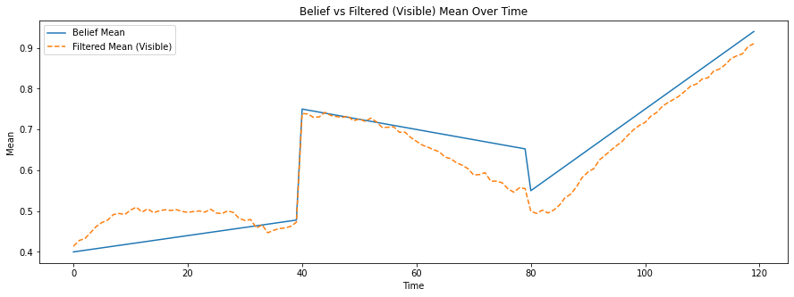

```
Q Matrix (VAR(1) Coefficients):
[[0.89406857 0.09672035]
 [0.91617995 0.09223281]]
```

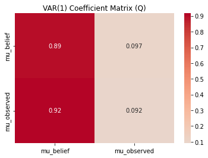

Let $Y_t$ be a $k$-dimensional vector time series following a VAR(1) model:

$$ Y_t = A Y_{t-1} + \varepsilon_t, \quad \varepsilon_t \sim \mathcal{N}(0, \Sigma) $$

The **impulse response function (IRF)** at horizon $h$ is defined as:

$$ \text{IRF}(h) = \frac{\partial Y_{t+h}}{\partial \varepsilon_t} $$

It measures the effect of a one-unit shock to the innovation $\varepsilon_t$ on the future value $Y_{t+h}$, holding all else constant.

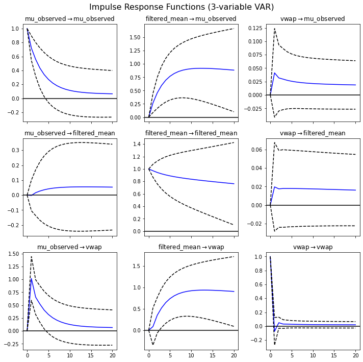

### Interpreting Impulse Response Function (IRF) Values

- **0 (Flat Line at Zero)**  
  The shock has **no effect** on that variable — the system is unresponsive. This is the baseline or "nothing happens" case.
- **+1 or -1 at Lag 0**  
  The shock itself is usually a **1-unit shock**, so you may see an **immediate jump of +1** in the shocked variable. Other variables may respond with smaller positive or negative values.
- **Positive IRF (> 0)**  
  A **positive response** means the variable increases in response to the shock.  
  Example: If `IRF_{filtered, observed}` is 0.2, then a 1-unit shock to `observed` leads to a +0.2 change in `filtered`.
- **Negative IRF (< 0)**  
  A **negative response** means the variable decreases in response to the shock.  
  This could indicate mean-reversion, price correction, or opposing force.
- **Persistent Response**  
  If the IRF **stays significantly above or below zero for several time steps**, it means the shock has a **lasting effect**.  
  This often implies **structural influence** — the variables are meaningfully linked.
- **Transient / Fading Response**  
  If the IRF **quickly returns to zero**, the shock has a **short-term effect** only.  
  This is typical in systems with little memory or quick adjustment.
- **Oscillating Response (up-down-up...)**  
  This suggests the system **overreacts then corrects**, possibly due to feedback loops or damping mechanisms.
- **Wide Confidence Bands**  
  Means the estimates are **noisy or uncertain** — be cautious interpreting the direction or strength of the effect.

### Summary Table

| IRF Pattern | Meaning |
| --- | --- |
| Flat at 0 | No effect |
| Spike then fade | Temporary, short-run effect |
| Sustained shift | Persistent influence |
| Oscillating | Feedback or over-correction |
| Positive/Negative | Direction of the response |

- **I think we should use a 3-variable VAR on observed mean, filtered mean, and VWAP**, since belief is made up and filtered mean is closer to what’s actually visible in the market.
- **Based on this, we can test how much predictive power the filtered (visible) signal has** — does it move VWAP, or is it just noise that survives rejection?
- **The end results should show whether observed shocks drive price directly, or whether the filtered mean adds incremental signal** beyond that.
- **We can package this as a visibility-based signal model**: observed is the noisy forecast, rejection sampling gives us what’s left over, and VAR dynamics show how that leftover signal actually influences price (VWAP).
- If the **filtered mean leads VWAP**, it supports using it as a real-time price signal — like a “latent liquidity curve” that predicts where trades don’t happen but pressure exists.
- If it **doesn’t move VWAP**, that tells us the rejection mechanism is just trimming noise, not uncovering signal — which still helps us calibrate the sharpness.
- Long term, this setup gives us a framework to **quantify the market's visible memory**, and potentially estimate belief dynamics **without ever observing belief directly**.